# Лабораторная работа № 6

Основы информационной безопасности

Казазаев Д. М.

Российский университет дружбы народов, Москва, Россия

# Информация

## Докладчик

- Казазаев Даниил Михайлович
- Студент бакалавриата
- Российский университет дружбы народов
- [1132231427@rudn.ru]
- https://github.com/KazazaevDaniil/study_2024-2025_infosec-intro

# Вводная часть

## Цели и задачи

Развитие навыков администрирования ОС Linux. Получение практических навыков в работе с технологией SELinux. Проверка работы SELinux совестно с Apache.

## Материалы и методы

Для выполнения лабораторной работы мы воспользуемся виртуальной машиной Oracle VM Virtual Box. Лабораторные работы выполняется на домашнем оборудовании.

## Содержание исследования

- Этапы работы
- 1. Выполнение лабораторной работы.

# Выполнение лабораторной работы.

## Выполнение лабораторной работы.

После запуска проверяю, работает-ли SELinux. (рис. 1)

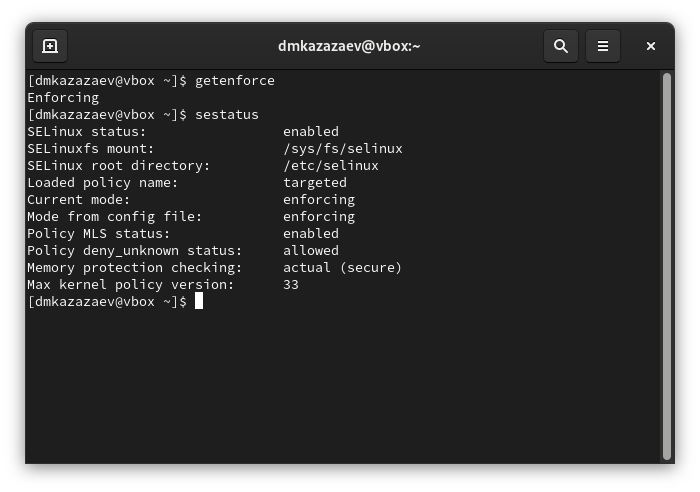

Информация о SELinux

## Выполнение лабораторной работы.

Проверяю запущен-ли Apache. Так как он не запущен, запускаю его. (рис. 2)

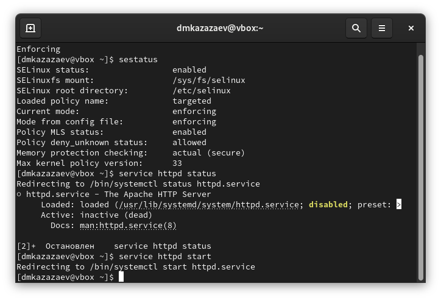

Проверка и запуск Apache

## Выполнение лабораторной работы.

Смотрю контекст безопасности веб-сервера Apache.(рис. 3)

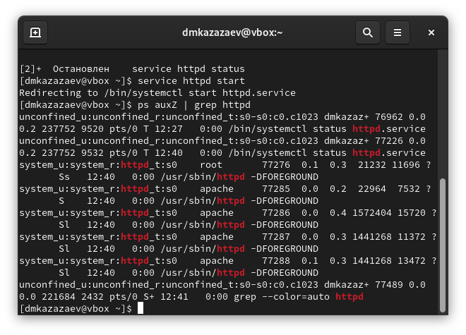

Контекст безопасности

## Выполнение лабораторной работы.

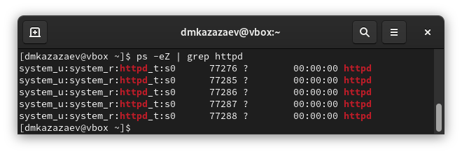

Контекст безопасности

## Выполнение лабораторной работы.

Смотрю состояние переключаетелей SELinux.(рис. 5)

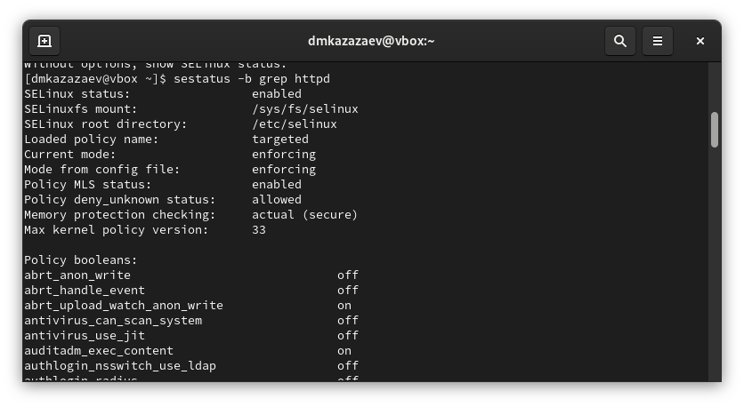

Состояние переключателей

## Выполнение лабораторной работы.

Смотрю статистику по политеке SELinux.(рис. 6)

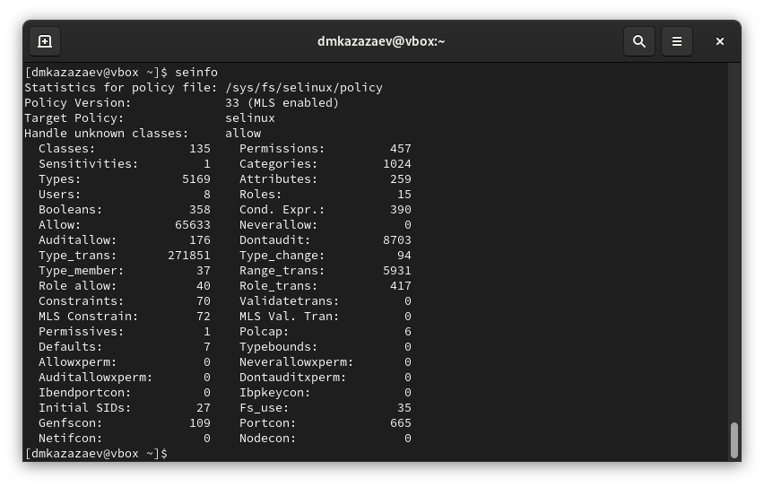

Статистика по политеке

## Выполнение лабораторной работы.

Смотрю, какие типы файлов есть в директории /var/www и права доступа к этим файлам.(рис. 7)

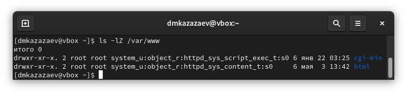

Контекст файлов в директории

## Выполнение лабораторной работы.

Создаю html файл в /var/www/html.(рис. 8)

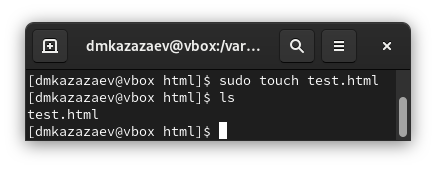

Создание html файла

## Выполнение лабораторной работы.

Переношу простую программу в созданный файл.(рис. 9)

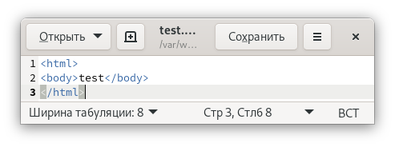

Код программы

## Выполнение лабораторной работы.

Проверяю контекст нового файла.(рис. 10)

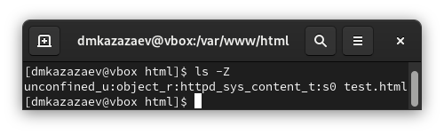

Контекст нового файла

## Выполнение лабораторной работы.

По умолчанию присваевается контекст вида `unconfident_u:object_r:httpd_sys_content_t:s0`

## Выполнение лабораторной работы.

Запускаю тестовый файл в веб-сервисе. (рис. 11)

[figure not shown]

Запущенный тестовый файл

## Выполнение лабораторной работы.

Изучаю, какие контексты могут быть присвоеный файлам. (рис. 12)

[figure not shown]

Справка по контекстам

## Выполнение лабораторной работы.

Детальнее изучаю контекст созданного файла. (рис. 13)

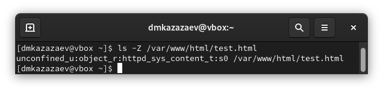

Контекст созданного файла

## Выполнение лабораторной работы.

Меняю контекст файла на `samba_share_t`. (рис. 14)

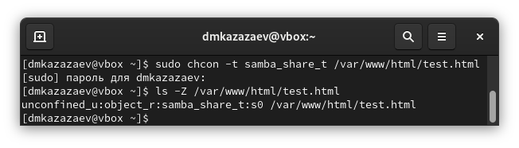

Меняю контекст

## Выполнение лабораторной работы.

После сменя контекста перезапускаю веб-сервис. При попытке запуска файла выводится ошибка прав доступа. (рис. 15)

[figure not shown]

Запуск файла с новым контекстом

## Выполнение лабораторной работы.

Недостаток доступа обусловлен тем, что новый контестк непубличный.

## Выполнение лабораторной работы.

Проверяю права доступа html файла. (рис. 16)

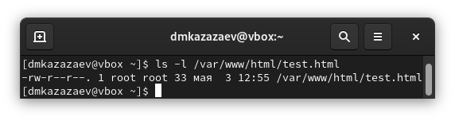

Проверка прав доступа

## Выполнение лабораторной работы.

В конфиг файле Apache меняю прослушивание TCP-порта на 81. (рис. 17)

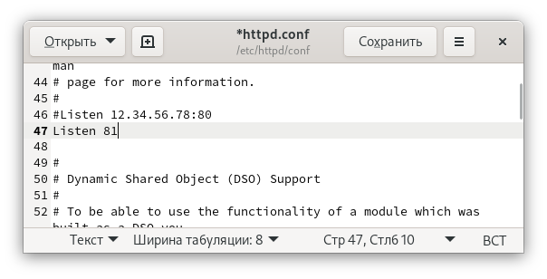

Смена TCP-порта

## Выполнение лабораторной работы.

Добавляю новый TCP-порт. (рис. 18)

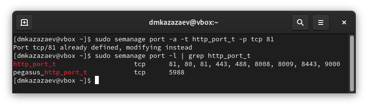

Добавление и проверка

## Выполнение лабораторной работы.

После добавление 81-го порта сайт должен был запуститься, но у меня этого не произошло.

## Выполнение лабораторной работы.

Удаляю новый порт. (рис. 19)

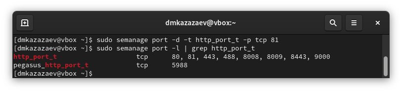

Удаление и проверка

## Выполнение лабораторной работы.

Удаляю созданный в ходе лабораторной работы html файл. (рис. 20)

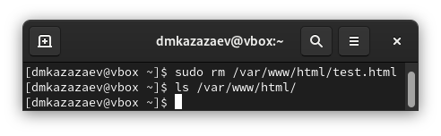

Удаление и проверка

# Вывод

В ходе лабораторной работы я познакомился с администрированием ОС Linux. Полученил практические навыкы в работе с технологией SELinux. Проверил работу SELinux совестно с Apache.